# 프로젝트 데이터 수집 결과와 기본 분석

김예슬 김정인

2020 6 24

# 프로젝트 개요

## 프로젝트 명

야구 응원관람객수가 많으면 야구팀의 승률이 높아질까?

## 프로젝트 수행 동기 및 이유

야구 관람의 가장 큰 묘미는 응원이다. 10개의 프로구단이 있고 구단마다 특색이 담긴 다양한 응원방법이 존재한다. 경기를 관람하는 사람을 신나게 할 정도로 야구 응원문화가 있지만, 한편으로는 야구장 주변 주민들의 소음피해로 손해배상 청구 소송이 일어나기도 한다. [1] 이처럼 장점도 있지만, 큰소리로 문제가 되기도 하는 응원이 선수들에게 경기를 이끌어 가는데 도움을 주는지 의문이 들었다. 실제로 야구장을 가보면 관객들은 큰 소리로 응원하는 반면에 선수들은 집중하기 위해서 관람석을 보지 않고 경기에 몰입해있다. 본팀은 야구장에 응원하러 가는 팬으로써 이 의문을 해소하기 위해서 이번 프로젝트의 주제로 선정하게 되었다.

## 프로젝트 목표

3.홈팀의 관중수와 승률의 상관관계를 알아보는 분석을 하고 결과를 도출한다.

# 데이터 수집

## 데이터 수집 결과

### 1.데이터 수집 크기

```r
format(object.size(final2018), units = "auto")
```

```
## [1] "55.4 Kb"
```

```r
format(object.size(final2019), units = "auto")
```

```
## [1] "36.5 Kb"
```

### 2.데이터 각 열에 대한 설명

1. x : 경기횟수
2. data : 날짜
3. home : 홈팀
4. homewin: 홈팀우승여부
5. visit : 원정팀
6. place : 경기장위치
7. number_audience : 관중수

# 기본 분석

## 개요

```r
test2018 <- read.csv("final2018.csv", fileEncoding = "UTF-8")
test2019 <- read.csv("final2019.csv", fileEncoding = "UTF-8")

summary(test2018)
```

```
##        X                 date         parks          away          home
##  Min.   :  0.0   2018/10/06:  6   잠실   :144   KIA    : 72   KIA    : 72
##  1st Qu.:179.8   2018/03/24:  5   고척   : 72   KT     : 72   KT     : 72
##  Median :359.5   2018/03/25:  5   마산   : 72   LG     : 72   LG     : 72
##  Mean   :359.5   2018/03/27:  5   문학   : 72   NC     : 72   NC     : 72
##  3rd Qu.:539.2   2018/03/28:  5   수원   : 72   SK     : 72   SK     : 72
##  Max.   :719.0   2018/03/29:  5   광주   : 69   넥센   : 72   넥센   : 72
##                  (Other)   :689   (Other):219   (Other):288   (Other):288
##  homewin    etcs        times     day          visit         place
##      :  3    :  3          :  3   금:108   KIA    : 72   잠실   :144
##  lose:327   -:717    14:00 :103   목:121   KT     : 72   고척   : 72
##  same:  6            15:00 :  4   수:129   LG     : 72   광주   : 72
##  win :384            17:00 :107   일:114   NC     : 72   마산   : 72
##                      18:00 : 55   토:124   SK     : 72   문학   : 72
##                      18:30 :447   화:124   넥센   : 72   수원   : 72
##                      19:00 :  1            (Other):288   (Other):216
##  number_audience
##  Min.   : 1515
##  1st Qu.: 6870
##  Median :10000
##  Mean   :11214
##  3rd Qu.:14320
##  Max.   :25000
##
```

```r
summary(test2019)
```

```
##        X               date         home.x        visit         place
##  Min.   :  1   2019/03/23:  5   KIA    : 72   KIA    : 72   잠실   :143
##  1st Qu.:180   2019/03/24:  5   KT     : 72   KT     : 72   고척   : 72
##  Median :359   2019/03/26:  5   LG     : 72   LG     : 72   광주   : 72
##  Mean   :359   2019/03/27:  5   NC     : 72   NC     : 72   문학   : 72
##  3rd Qu.:538   2019/03/28:  5   SK     : 72   두산   : 72   수원   : 72
##  Max.   :717   2019/03/29:  5   롯데   : 72   롯데   : 72   창원   : 72
##                (Other)   :687   (Other):285   (Other):285   (Other):214
##  number_audience homewin
##  Min.   : 1158   lose:318
##  1st Qu.: 6355   same:  7
##  Median : 8691   win :392
##  Mean   :10105
##  3rd Qu.:12761
##  Max.   :25000
##
```

경기(x)는 년도별로 710여번 치뤄졌고, 홈(home)과 방문(visit)인 경기가 각 팀별로 일정하게 치뤄지고 있는 것을 볼 수 있다.

홈팀 승리(homewin)변수를 보면 홈팀이 이기는 횟수가 패배보다 많은 것을 볼 수 있다.

또한, 관객수(number_audience)는 최소, 최대, 평균값을 보면 2018-2019년이 비슷한 추세를 기록하고 있는 것을 볼 수 있다.

## 변수별 분석

### 1.2018-2019년의 구단별 홈경기장의 승패 횟수를 표로 표현하였다.

```r
table2 <- xtabs(~home + homewin, data=test2018)
table2
```

```
##       homewin
## home      lose same win
##   KIA   3   27    0  42
##   KT    0   39    2  31
##   LG    0   32    1  39
##   NC    0   39    0  33
##   SK    0   31    0  41
##   넥센  0   35    0  37
##   두산  0   21    0  51
##   롯데  0   38    0  34
##   삼성  0   36    3  33
##   한화  0   29    0  43
```

```r
table1 <- xtabs(~home.x + homewin, data=test2019)
table1
```

```
##       homewin
## home.x lose same win
##   KIA    33    0  39
##   KT     30    1  41
##   LG     30    1  41
##   NC     30    2  40
##   SK     27    1  44
##   두산   25    0  46
##   롯데   42    1  29
##   삼성   36    0  36
##   키움   26    1  45
##   한화   39    0  31
```

2018년에는 삼성, 롯데, NC, KT와 2019년에는 롯데, 삼성, 한화를 제외하고는 다른 구단들은 홈경기장에서 경기를 치루면 높은 승리를 거둔 것을 볼 수 있다.

### 2. 2018-2019년 구단별 홈경기장 관객 수이다.

아래의 표는 2018,2019년 각각의 구단별 관객수의 평균, 최소, 최대, 총합을 보여주는 표이다.

```r
#2018
a18 <- test2018 %>% group_by(home) %>%
   summarize(mean_au=mean(number_audience),max_au=max(number_audience),min_au=min(number_audience), total_au=sum(number_audience))
a18 <- arrange(a18, desc(total_au))
a18
```

| home | mean_au | max_au | min_au | total_au |
| --- | --- | --- | --- | --- |
| 두산 | 15445.361 | 25000 | 7119 | 1112066 |
| LG | 15398.292 | 25000 | 5512 | 1108677 |
| SK | 14405.708 | 25000 | 4254 | 1037211 |
| 롯데 | 12522.694 | 25000 | 3709 | 901634 |
| KIA | 11968.458 | 20500 | 5484 | 861729 |
| 삼성 | 10448.750 | 24000 | 3216 | 752310 |
| 한화 | 10195.972 | 13000 | 3891 | 734110 |
| KT | 9285.542 | 20800 | 3189 | 668559 |
| 넥센 | 6313.528 | 15055 | 1515 | 454574 |
| NC | 6151.000 | 11000 | 2768 | 442872 |

```r
#2019
a19 <- test2019 %>% group_by(home.x) %>%
   summarize(mean_au=mean(number_audience), max_au=max(number_audience), min_au=min(number_audience),total_au=sum(number_audience))
a19 <- arrange(a19, desc(total_au))
a19
```

| home.x | mean_au | max_au | min_au | total_au |
| --- | --- | --- | --- | --- |
| LG | 13894.444 | 25000 | 6670 | 1000400 |
| SK | 13652.250 | 23000 | 5148 | 982962 |
| 두산 | 13534.662 | 25000 | 5427 | 960961 |
| NC | 9864.917 | 22112 | 4438 | 710274 |
| KIA | 9613.375 | 20500 | 4171 | 692163 |
| 삼성 | 9606.681 | 24000 | 2801 | 691681 |
| 롯데 | 9433.444 | 24500 | 1762 | 679208 |
| KT | 7454.653 | 17899 | 2903 | 536735 |
| 한화 | 7667.471 | 13000 | 3841 | 536723 |
| 키움 | 6303.972 | 13115 | 1158 | 453886 |

아래의 그래프는 2018,2019년의 위의 표를 그래프로 보여준다.

막대그래프는 평균, 빨간 선그래프는 최소관객수, 파란선그래프는 최대관객수를 표현한다.

[figure not shown]

```r
#2018
ggplot() + geom_col(aes(x=home, y=mean_au, color=home), data=a18) +
  geom_line(aes(x=home, min_au),col="red", group=1,  data=a18) +
  geom_line(aes(x=home, max_au), col="blue", group=1, data=a18)
```

[figure not shown]

```r
#2019
ggplot() + geom_col(aes(x=home.x, y=mean_au, color=home.x), data=a19) +
  geom_line(aes(x=home.x, min_au),col="red", group=1, data=a19) +
  geom_line(aes(x=home.x, max_au), col="blue", group=1, data=a19)
```

표와 그래프를 보면 2018-2019년 각기 차이가 있지만 두산, LG, SK가 일정하게 높은 관객수를 기록하고 있는 것을 보여주고 있다.

## 상관성 분석

### 1.homewin열을 원핫인코딩

```r
#2018
#원핫인코딩
new2018<-transform(test2018,
                   win = ifelse(homewin =="win", 1, 0),
                   lose = ifelse(homewin =="lose", 1, 0),
                   same = ifelse(homewin =="same", 1, 0))
head(new2018)
```

|  | X | date | parks | away | home | homewin | etcs | times | day | visit | place | number_audience | win | lose | same |
| --- | --- | --- | --- | --- | --- | --- | --- | --- | --- | --- | --- | --- | --- | --- | --- |
| 1 | 0 | 2018/03/24 | 문학 | 롯데 | SK | win | - | 14:00 | 토 | 롯데 | 문학 | 25000 | 1 | 0 | 0 |
| 2 | 1 | 2018/03/25 | 문학 | 롯데 | SK | win | - | 14:00 | 일 | 롯데 | 문학 | 22765 | 1 | 0 | 0 |
| 3 | 2 | 2018/03/27 | 문학 | KT | SK | win | - | 18:30 | 화 | KT | 문학 | 6067 | 1 | 0 | 0 |
| 4 | 3 | 2018/03/28 | 문학 | KT | SK | lose | - | 18:30 | 수 | KT | 문학 | 5701 | 0 | 1 | 0 |
| 5 | 4 | 2018/03/29 | 문학 | KT | SK | lose | - | 18:30 | 목 | KT | 문학 | 5936 | 0 | 1 | 0 |
| 6 | 5 | 2018/03/30 | 대전 | SK | 한화 | lose | - | 18:30 | 금 | SK | 대전 | 10354 | 0 | 1 | 0 |

```r
#2019
#원핫인코딩
new2019<-transform(test2019,
                   win = ifelse(homewin =="win", 1, 0),
                   lose = ifelse(homewin =="lose", 1, 0),
                   same = ifelse(homewin =="same", 1, 0))
head(new2019)
```

|  | X | date | home.x | visit | place | number_audience | homewin | win | lose | same |
| --- | --- | --- | --- | --- | --- | --- | --- | --- | --- | --- |
| 1 | 1 | 2019/03/23 | KIA | LG | 광주 | 20500 | lose | 0 | 1 | 0 |
| 2 | 2 | 2019/03/23 | NC | 삼성 | 창원 | 22112 | win | 1 | 0 | 0 |
| 3 | 3 | 2019/03/23 | SK | KT | 문학 | 21909 | win | 1 | 0 | 0 |
| 4 | 4 | 2019/03/23 | 두산 | 한화 | 잠실 | 25000 | win | 1 | 0 | 0 |
| 5 | 5 | 2019/03/23 | 롯데 | 키움 | 사직 | 24500 | lose | 0 | 1 | 0 |
| 6 | 6 | 2019/03/24 | KIA | LG | 광주 | 17597 | lose | 0 | 1 | 0 |

상관계수를 구하기 위해 범주형 변수를 원핫인코딩한다.

### 2.cor()을 통한 상관계수 구하기

2018년-2019년의 관객수와 win(승)열과의 각각의 상관계수를 구한 결과,

두 해 모두 관객수와 win(승)은 0에 가까운 수를 보여 두 변수의 선형 상관성이 없다.

```r
#2018
cor(new2018$number_audience, new2018$win, use = "complete.obs")
```

```
## [1] 0.05199886
```

```r
#2019
cor(new2019$number_audience, new2019$win, use = "complete.obs")
```

```
## [1] 0.06795763
```

# 가설검정

## 가설1. 2018-2019의 년도별 승패에 따른 평균 관객수의 차이가 없을 것이다.

2018년-2019년의 승패에 따른 평균 관객수에 대한 가설검정

귀무가설(H_0) : 승패에 따른 평균의 차가 0일 것이다.

대립가설(H_1) : 승패에 따른 평균의 차가 0이 아닐 것이다.

- 승패 데이터 추출

```r
#2018년
new2018_2 <- filter(new2018, homewin=="lose" | homewin=="win")
#2019년
new2019_2 <- filter(new2019, homewin=="lose" | homewin=="win")
```

- 2018-2019년 별 관객수 통계량

-2018년

```r
#2018년
new2018_2 %>%group_by(homewin) %>%
  summarise(mean=mean(number_audience),median=median(number_audience),
            sd=sd(number_audience),mad=mad(number_audience),
            skew=psych::skew(number_audience),kurtosis=psych::kurtosi(number_audience))
```

| homewin | mean | median | sd | mad | skew | kurtosis |
| --- | --- | --- | --- | --- | --- | --- |
| lose | 10913.21 | 9393 | 5768.509 | 4877.754 | 0.8613956 | -0.04217497 |
| win | 11497.95 | 10435 | 5925.151 | 5547.148 | 0.6187005 | -0.42076800 |

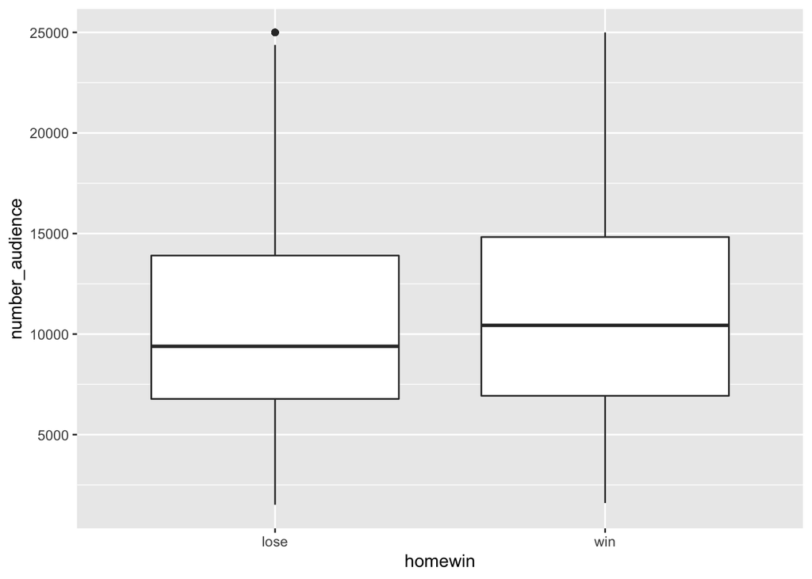

```r
ggplot(new2018_2) + geom_boxplot(aes(homewin, number_audience), norch=T)
```

-2019년

```r
#2019년
new2019_2 %>%group_by(homewin) %>%
  summarise(mean=mean(number_audience),median=median(number_audience),
            sd=sd(number_audience),mad=mad(number_audience),
            skew=psych::skew(number_audience),kurtosis=psych::kurtosi(number_audience))
```

| homewin | mean | median | sd | mad | skew | kurtosis |
| --- | --- | --- | --- | --- | --- | --- |
| lose | 9713.421 | 8220.5 | 5039.700 | 4005.244 | 1.0215695 | 0.5996048 |
| win | 10423.033 | 9145.5 | 5252.511 | 4603.473 | 0.8996903 | 0.1257970 |

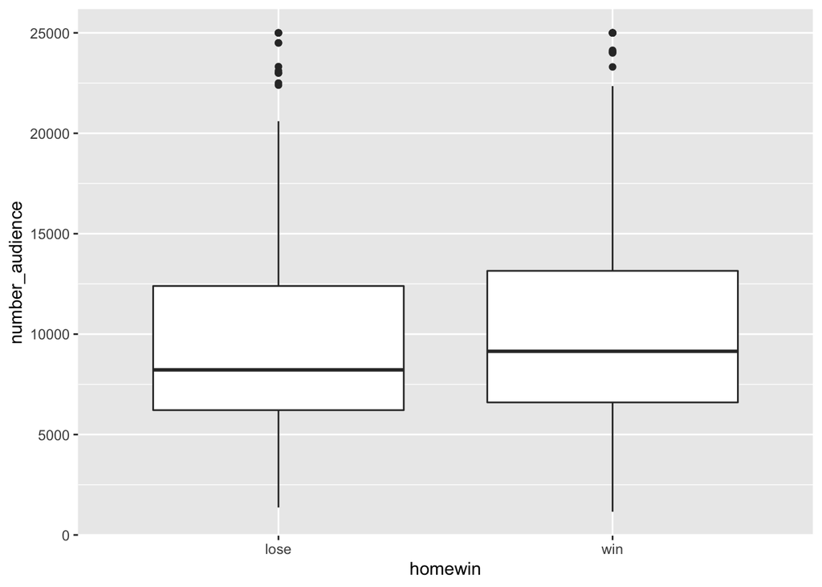

```r
ggplot(new2019_2) + geom_boxplot(aes(homewin, number_audience), norch=T)
```

- 가설검정

-2018년

```r
#2018년
t.test(number_audience ~ homewin, data=new2018_2)
```

```
##
##  Welch Two Sample t-test
##
## data:  number_audience by homewin
## t = -1.3304, df = 696.43, p-value = 0.1838
## alternative hypothesis: true difference in means is not equal to 0
## 95 percent confidence interval:
##  -1447.6989   278.2242
## sample estimates:
## mean in group lose  mean in group win
##           10913.21           11497.95
```

-2019년

```r
#2019년
t.test(number_audience ~ homewin, data=new2019_2)
```

```
##
##  Welch Two Sample t-test
##
## data:  number_audience by homewin
## t = -1.8307, df = 688.43, p-value = 0.06758
## alternative hypothesis: true difference in means is not equal to 0
## 95 percent confidence interval:
##  -1470.67162    51.44806
## sample estimates:
## mean in group lose  mean in group win
##           9713.421          10423.033
```

2018-2019년 모두 신뢰구간 95%로 p-value가 0.05를 넘으므로 귀무가설을 채택한다.

따라서, 승패별 평균 관객수 차이는 없다.

## 추가적인 가설 검정

전체데이터가 아닌 범위를 좁혀서 가설검정을 해보기로 하였다.

2018-2019년 1등팀과 10등팀 각각의 승패에 따른 평균 관객수의 가설 검정이다.

1. 2018-2019년 1등팀 가설 검정

가설. 2018-2019의 1등 팀의 년도별 승패에 따른 평균 관객수의 차이가 없을 것이다.

2018년-2019년의 1등 팀의 승패에 따른 평균 관객수에 대한 가설검정

귀무가설(H_0) : 승패에 따른 평균의 차가 0일 것이다.

대립가설(H_1) : 승패에 따른 평균의 차가 0이 아닐 것이다.

- 데이터 추출 : 2018년 SK와 2019년 두산

```r
#home이 "SK"인 행만 추출
winner_2018 <- new2018[new2018$home=="SK",]
#home이"두산"인 행만 추출
winner_2019 <- new2019[new2019$home.x=="두산",]
```

- 팀별 관객수 통계량

-2018년 SK

```r
# 2018년 SK
winner_2018 %>%group_by(win) %>%
  summarise(mean=mean(number_audience),median=median(number_audience),
            sd=sd(number_audience),mad=mad(number_audience),
            skew=psych::skew(number_audience),kurtosis=psych::kurtosi(number_audience))
```

| win | mean | median | sd | mad | skew | kurtosis |
| --- | --- | --- | --- | --- | --- | --- |
| 0 | 14654.26 | 14028 | 6901.013 | 10219.562 | 0.11697795 | -1.516941 |
| 1 | 14217.78 | 14451 | 6605.316 | 8965.282 | 0.07497759 | -1.326153 |

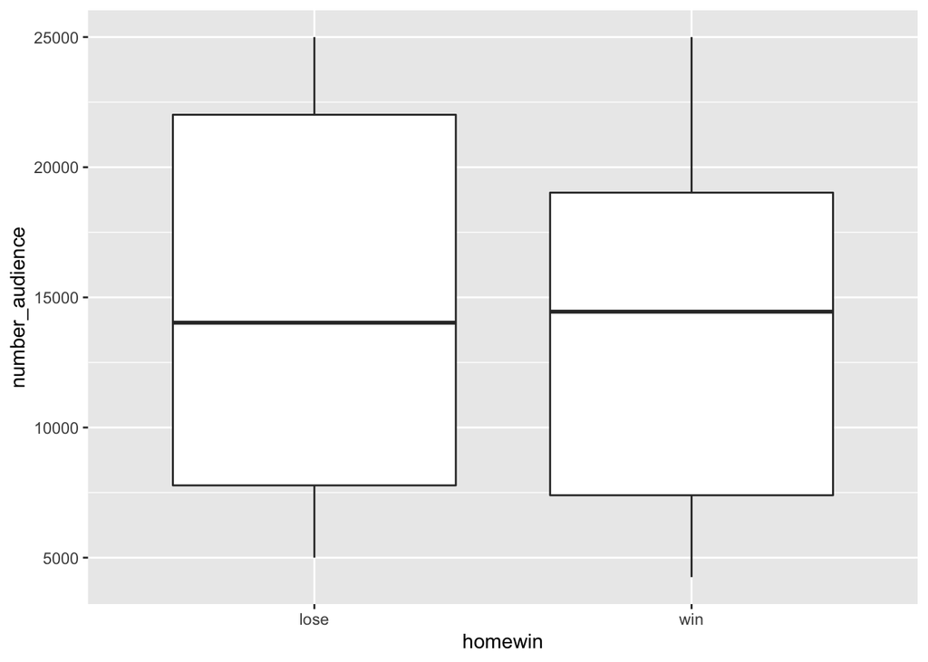

```r
#boxplot
ggplot(winner_2018) + geom_boxplot(aes(homewin, number_audience), norch=T)
```

-2019년 두산

```r
# 2019년 두산
winner_2019 %>%group_by(win) %>%
  summarise(mean=mean(number_audience),median=median(number_audience),
            sd=sd(number_audience),mad=mad(number_audience),
            skew=psych::skew(number_audience),kurtosis=psych::kurtosi(number_audience))
```

| win | mean | median | sd | mad | skew | kurtosis |
| --- | --- | --- | --- | --- | --- | --- |
| 0 | 13029.16 | 12127 | 5136.556 | 5279.539 | 0.6519054 | -0.5470352 |
| 1 | 13809.39 | 12240 | 6144.343 | 6137.223 | 0.5110643 | -0.8954212 |

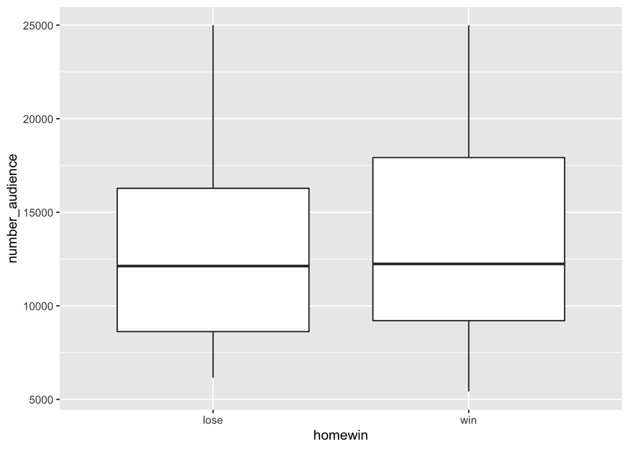

```r
ggplot(winner_2019) + geom_boxplot(aes(homewin, number_audience), norch=T)
```

- 가설검정

-2018년 SK

```r
t.test(number_audience~win, data=filter(winner_2018))
```

```
##
##  Welch Two Sample t-test
##
## data:  number_audience by win
## t = 0.27067, df = 63.209, p-value = 0.7875
## alternative hypothesis: true difference in means is not equal to 0
## 95 percent confidence interval:
##  -2785.794  3658.749
## sample estimates:
## mean in group 0 mean in group 1
##        14654.26        14217.78
```

-2019년 두산

```r
t.test(number_audience~win, data=filter(winner_2019))
```

```
##
##  Welch Two Sample t-test
##
## data:  number_audience by win
## t = -0.56964, df = 57.346, p-value = 0.5711
## alternative hypothesis: true difference in means is not equal to 0
## 95 percent confidence interval:
##  -3522.655  1962.192
## sample estimates:
## mean in group 0 mean in group 1
##        13029.16        13809.39
```

2018-2019년 모두 신뢰구간 95%로 p-value가 0.05를 넘으므로 귀무가설을 채택한다.

따라서, 1등 팀별 승패별 평균 관객수 차이는 없다.

2. 2018-2019년 10등팀 가설 검정

가설. 2018-2019의 10등 팀의 년도별 승패에 따른 평균 관객수의 차이가 없을 것이다.

2018년-2019년의 10등 팀의 승패에 따른 평균 관객수에 대한 가설검정

귀무가설(H_0) : 승패에 따른 평균의 차가 0일 것이다.

대립가설(H_1) : 승패에 따른 평균의 차가 0이 아닐 것이다.

- 데이터 추출 : 2018년 NC와 2019년 롯데

```r
#2018년
loser_2018 <- new2018[new2018$home=="NC",]
#2019년
loser_2019 <- new2019[new2019$home.x=="롯데",]
```

- 팀별 관객수 통계량

-2018년 NC

```r
# 2018년 NC
loser_2018 %>%group_by(lose) %>%
  summarise(mean=mean(number_audience),median=median(number_audience),
            sd=sd(number_audience),mad=mad(number_audience),
            skew=psych::skew(number_audience),kurtosis=psych::kurtosi(number_audience))
```

| lose | mean | median | sd | mad | skew | kurtosis |
| --- | --- | --- | --- | --- | --- | --- |
| 0 | 5651.030 | 4838 | 2293.373 | 1141.602 | 1.0920177 | 0.02426259 |
| 1 | 6574.051 | 6242 | 1961.080 | 2499.664 | 0.1024458 | -0.70645112 |

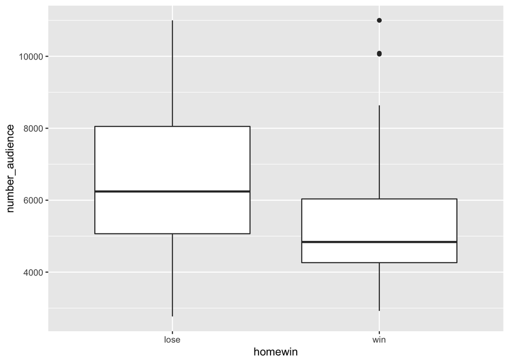

```r
#boxplot
ggplot(loser_2018) + geom_boxplot(aes(homewin, number_audience), norch=T)
```

-2019년 롯데

```r
# 2019년 롯데
loser_2019 %>%group_by(lose) %>%
  summarise(mean=mean(number_audience),median=median(number_audience),
            sd=sd(number_audience),mad=mad(number_audience),
            skew=psych::skew(number_audience),kurtosis=psych::kurtosi(number_audience))
```

| lose | mean | median | sd | mad | skew | kurtosis |
| --- | --- | --- | --- | --- | --- | --- |
| 0 | 10608.867 | 8985 | 5545.408 | 4256.545 | 0.7805529 | -0.5150594 |
| 1 | 8593.857 | 7514 | 5635.601 | 5364.047 | 1.1565135 | 1.0000941 |

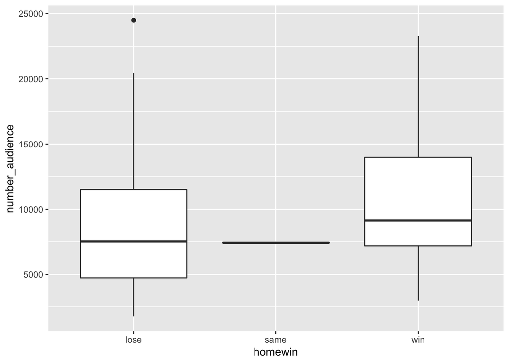

```r
ggplot(loser_2019) + geom_boxplot(aes(homewin, number_audience), norch=T)
```

- 가설검정

-2018년 NC

```r
t.test(number_audience~win, data=filter(loser_2018))
```

```
##
##  Welch Two Sample t-test
##
## data:  number_audience by win
## t = 1.8172, df = 63.407, p-value = 0.07391
## alternative hypothesis: true difference in means is not equal to 0
## 95 percent confidence interval:
##   -91.86636 1937.90832
## sample estimates:
## mean in group 0 mean in group 1
##        6574.051        5651.030
```

-2019년 롯데

```r
t.test(number_audience~win, data=filter(loser_2019))
```

```
##
##  Welch Two Sample t-test
##
## data:  number_audience by win
## t = -1.6012, df = 59.95, p-value = 0.1146
## alternative hypothesis: true difference in means is not equal to 0
## 95 percent confidence interval:
##  -4841.4790   536.4782
## sample estimates:
## mean in group 0 mean in group 1
##        8566.465       10718.966
```

2018-2019년 모두 신뢰구간 95%로 p-value가 0.05를 넘으므로 귀무가설을 채택한다.

따라서, 10등 팀별 승패별 평균 관객수 차이는 없다.

## 결론

[figure not shown]

```r
ggplot(new2018_2) + geom_boxplot(aes(homewin, number_audience,fill=home), norch=T)
```

[figure not shown]

```r
ggplot(new2019_2) + geom_boxplot(aes(homewin, number_audience,fill=home.x), norch=T)
```

# 출처

[1] 위키백과, 대한민국의 야구 응원 문화 https://ko.wikipedia.org/wiki/%EB%8C%80%ED%95%9C%EB%AF%BC%EA%B5%AD%EC%9D%98_%EC%95%BC%EA%B5%AC_%EC%9D%91%EC%9B%90_%EB%AC%B8%ED%99%94#%EB%B9%84%ED%8C%90 [2] KBO, 일자별 관중수, https://www.koreabaseball.com/History/Crowd/GraphDaily.aspx [3] github, KBO 승패 데이터, https://github.com/kimchangkyu/Prediction_of_Attendance_in_KBO/blob/master/datas/kbo_results.csv